# Polsby-Popper Implementation

We’ve made it to the product & notebook! If you haven’t already, I highly recommend taking a look at some of the [background](https://docs.google.com/document/d/1OQTgmXHjPGqqkdi6Bjtnv-1R8RsECKapcShh1BSVkP8/edit), [calculus behind it](https://docs.google.com/document/d/1szI_HP9G6EKDzKEqEny2MOMrd5ONHBL6l53go19a0uo/edit), or especially the [isoperimetric quotient](https://docs.google.com/document/d/1GY4eSb0_ABNp01JnLETtMQCxW1d2P7xvJxFYSoX7lc4/edit). This is going to assume you have all of that information.

Let’s get started.

## Recap

To recap, we have the isoperimetric quotient:
$$Q=\frac{4\pi A_s}{L^2}$$
.

$A_s$ is the area of whatever shape we’re measuring and $L$ is its perimeter. We can always say for any closed shape that $0\leq Q\leq 1$ because of the isoperimetric inequality: $L^2 \geq 4\pi A$.

Where does this quotient come from? Well, we’ve established that a circle is the “perfect” shape in so far that for a given perimeter $L$, a circle encompasses the maximum area possible. So we can take any irregular shape with a perimeter $L$ and area $A_s$ and find a circle with the same perimeter. That circle’s area, $A_c$, will always be greater than $A_s$ by the isoperimetric inequality. We therefore define the ratio of the two, $\frac{A_s}{A_p}$, as the isoperimetric quotient. (The actual math behind this is in the supplementary document linked above labeled the isoperimetric quotient - I **highly** recommend you skim it!)

This is a great measure of compactness because shapes that are less compact will have lesser area enclosed in a greater perimeter. So this quotient, also known as the **Polsby-Popper algorithm** will tell us how compact a certain shape, or perhaps geographic region is.

## Gerrymandering

Let’s talk a little bit about gerrymandering. “Gerrymandering” is the process of redistricting to favor a certain group: perhaps a political party, a politician, a majority (or minority). Every 10 years, when our Congressional districts change, gerrymandered districts spring up all across the US as politicians attempt to skew the maps to help a certain group (often one they are associated with, surprise surprise). Here’s a representation:

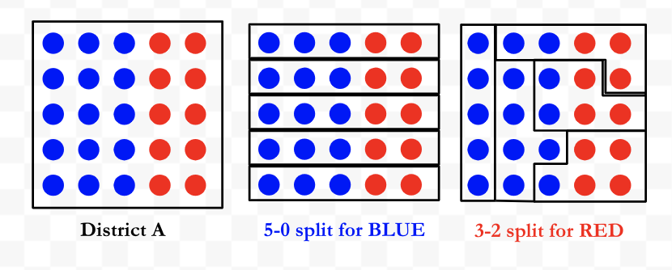

Representation of Gerrymandering

We see that with the same map, we’re able to group it so that BLUE has an outright 5-0 majority OR RED, despite being in the minority, has a 3-2 majority in districts. But notably, gerrymandered districts are less compact; they require *cracking* or *packing*.

Cracking involves taking a group, say RED, and distributing them across districts, as in the 5-0 majority. Packing, on the contrary, involves placing a group in one district so that they aren’t part of others, like BLUE’s 2 districts in the 3-2 RED majority. Because their voting power is concentrated in those two districts, RED is free to take the majority. While the measures don’t affect compactness too much here, on a larger scale, these methods difficult to use without drawing some weird shapes.

The isoperimetric quotient, or Polsby-Popper algorithm, is exactly how we examine just how weirdly shaped a gerrymandered district is. So let’s try it!

## Parametrics

This notebook has curves that we can apply our area and arc length equations for parametrics to, and thenm, it has real districts that we can test Polsby-Popper on.

If we have parametric equations $x=f(t), y=g(t)$, and we’re looking at the interval $\alpha \leq t\leq \beta$ (where $f(t)$, $g(t)$, $f'(t)$, and $g'(t)$ are all continuous over the interval) we define area $A$ and arc length $L$ as so:
$$A = \int_\alpha^\beta g(t)f'(t)dt, \ \ \ \
L=\int_\alpha^\beta
\sqrt{\left(\frac{dx}{dt}\right)^2+\left(\frac{dy}{dt}\right)^2}dt$$
We’ll have the program calculate these integrals for us, especially for some of the more complicated integrals. But know that a lot of these (if not all) can be done by hand!! And you can find the basic application for a circle as well as the Lagrange derivation in supplementary materials.

## Algorithm

Let’s create a function for the algorithm.

```r
# importing some R libraries
library(ggplot2)
library(patchwork)
library(dplyr)
library(Deriv)
library(numDeriv)
library(stats)
```

First, let’s define arc length.

```r
arc_length = function(x, y, lower, upper) {

  # we are essentially finding dx/dt and dy/dt for our x_func and y_func in terms of parameter t
  dx_dt = function(t) {
    eval(deriv(expression(x), "t"))(t)
  }
  dy_dt = function(t) {
    eval(deriv(expression(y), "t"))(t)
  }

  # to operate with these functions, we need to vectorize them!
  dx_dt_vect = Vectorize(dx_dt)
  dy_dt_vect = Vectorize(dy_dt)

  # we can compute our integrandnow with those vector functions
  integrand = function(t) {
    sqrt(dx_dt_vect(t)^2 + dy_dt_vect(t)^2)
  }

  # and now we integrate!
  return(integrate(integrand, lower, upper)$value)

}
```

Now, we’ll create a function for parametric area.

```r
# this is a little bit different because R becomes buggy when we integrate for parametric area isn't too accurate in R
# so we have to use a trapezoidal Riemann sum!
# but when we have say, 1000 trapezoids, in such a short interval, it becomes a okay
area = function(x, y, lower, upper, n = 10000) {

  # these are all of our points in our t bounds for the Riemann sum
  t_set = seq(lower, upper, length.out = n)

  # now we calculate the necessary values at each point
  y_set = sapply(t_set, y)
  dx_dt_set = sapply(t_set, function(t) {
    grad(x, t)
  })
  # the grad function is another way of taking the derivative

  # finally, we perform the integration; we multiply y by dx/dt before integrating for dt (the differential of each t point)
  # we also just take the absolute value to ensure consistency (no negative areas!)
  return(abs(sum(y_set * dx_dt_set * diff(t_set))))
}
```

Let’s now combine these to calculate the isoperimetric quotient $Q$, or our Polsby-Popper output!

```r
polsby_popper = function(x, y, lower, upper, add=0) {
  # we find L with our given values
  # add accounts for any borders the parametric equation doesn't capture
  L = arc_length(x, y, lower, upper) + add
  # same thing for A
  A = area(x, y, lower, upper)
  # returning the quotient

  return((4*pi*A)/L^2)
}
```

Finally, we’ll just code a plotting function so we can visualize all the shapes we’re generating.

```r
plot_function = function(x, y, lower, upper, n=1000) {
  # we're performing the same thing; generating many points that we can then plot
  t_set = seq(lower, upper, length.out = n)

  # we find sets for x and y
  x_set = sapply(t_set, x)
  y_set = sapply(t_set, y)

  # now we put this in a dataframe so we can plot it
  graph = data.frame(t=t_set, x=x_set, y=y_set)

  # plotting function
  ggplot(graph, aes(x = x, y = y)) +
    geom_path(color = "blue", size = 1, linetype = "solid") +
    labs(x = "x", y = "y") +
    theme(plot.title = element_text(hjust = 0.5, size = 14),
        axis.text = element_text(size = 12),
        axis.title = element_text(size = 14)) + coord_equal()
}
```

## Applications on Smooth Curves

Now that we have those functions, let’s do some testing! First, for a circle, we expect a Polsby-Popper coefficient of 1.
$$x(t)=\cos (t)$$
$$y(t)=\sin(t)$$
$$0 \leq t \leq 2\pi$$

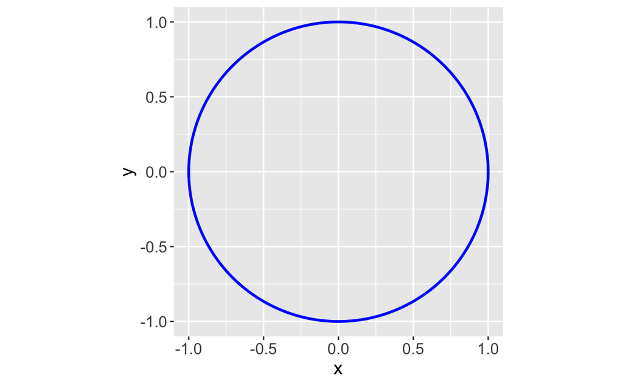

```r
# here are our parametric equations for a circle -- let's plot them first
x = function(t) cos(t)
y = function(t) sin(t)

plot_function(x, y, 0, 2*pi)
```

```r
# we can now apply Polsby-Popper and get our value
print(suppressWarnings(paste("Arc Length:", arc_length(x,y, 0, 2*pi))))
```

```
[1] "Arc Length: 6.28318530717959"
```

```r
print(suppressWarnings(paste("Area:", area(x,y, 0, 2*pi))))
```

```
[1] "Area: 3.14159265358971"
```

```r
print(suppressWarnings(paste("Polsby-Popper:", polsby_popper(x,y, 0, 2*pi))))
```

```
[1] "Polsby-Popper: 0.999999999999974"
```

And we get 1! That makes sense– it’s the most compact shape.

We’ll now repeat with an ellipse; circular, but slightly stretched out. Our equations are:
$$x(t)=2\cos
(t)$$
$$y(t)=\sin(t)$$
$$0 \leq t \leq 2\pi$$

```r
x = function(t) 2*cos(t)
y = function(t) sin(t)
print(suppressWarnings(paste("Arc Length:", arc_length(x,y, 0, 2*pi))))
```

```
[1] "Arc Length: 9.68844822054768"
```

```r
print(suppressWarnings(paste("Area:", area(x,y, 0, 2*pi))))
```

```
[1] "Area: 6.28318530717942"
```

```r
print(suppressWarnings(paste("Polsby-Popper:", polsby_popper(x,y, 0, 2*pi))))
```

```
[1] "Polsby-Popper: 0.841165181006297"
```

And here’s our plotted function!

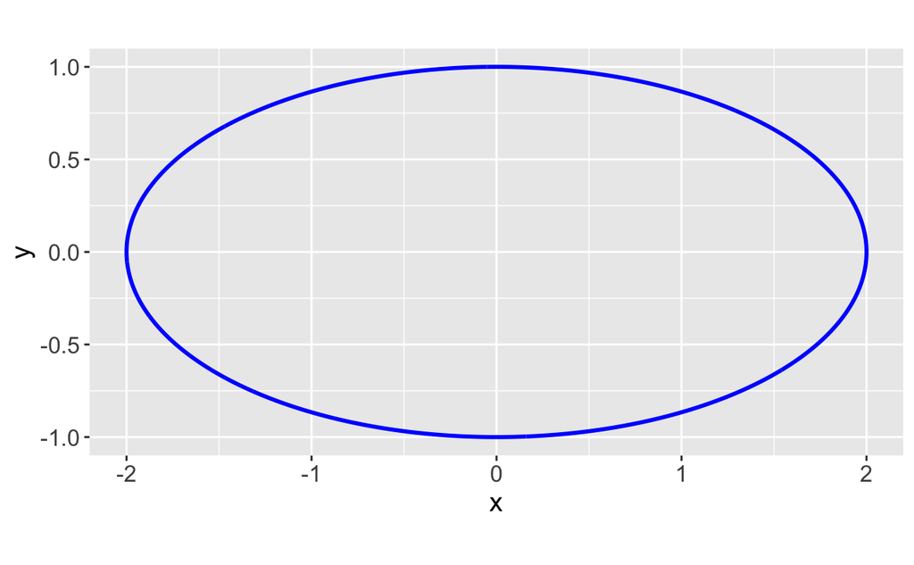

```r
plot_function(x, y, 0, 2*pi)
```

So we can pretty easily visualize that it’s still relatively “compact,” and it follows that the Polsby-Popper value is high.

What about shapes with some sharp edges? Let’s do it. This one is relatively simple.
$$x(t)=t^2$$
$$y(t)=t$$
$$0\leq t \leq 2$$
Let’s plot it and calculate the Polsby-Popper.

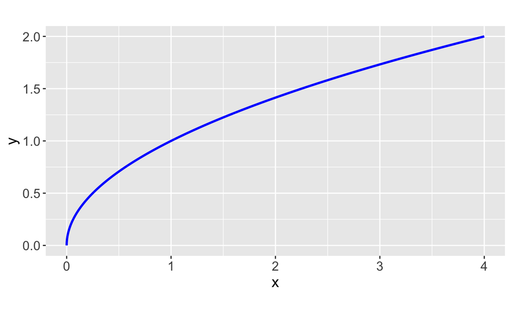

```r
x = function(t) t^2
y = function(t) t

plot_function(x, y, 0, 2)
```

```r
print(suppressWarnings(paste("Arc Length:", arc_length(x,y, 0, 2) + 6)))
```

```
[1] "Arc Length: 9.39344662916632"
```

```r
print(suppressWarnings(paste("Area:", area(x,y, 0, 2))))
```

```
[1] "Area: 5.33413344001319"
```

```r
print(suppressWarnings(paste("Polsby-Popper:", polsby_popper(x,y, 0, 2, 6))))
```

```
[1] "Polsby-Popper: 0.759667935031607"
```

But note what I’ve done here. I added “6” to the arc length. Why? It’s because when we’re parametrizing the curves, we don’t consider the added borders on the x and y! If we consider the complete shape, we thus must add 6 (4 on the x-axis, 2 on x=4) to adequately capture our border.

The value of 0.76 is still relatively good, telling us that just because districts have sharp borders doesn’t automatically disqualify them.

Now let’s look at two examples that are…not so compact:

$$x(t) = e^t$$
$$y(t) = 3\sin(t)$$
$$0 \leq t \leq 3$$

Plotting it:

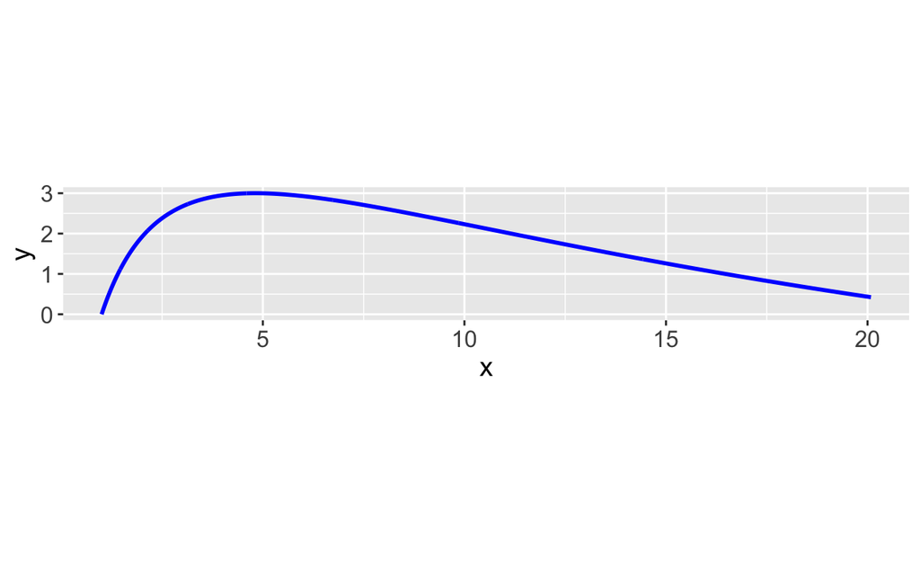

```r
x = function(t) exp(t)
y = function(t) 3*sin(t)

plot_function(x, y, 0, 3)
```

This looks like an odd shape, but it’s going to tell us what happens when we try to create really thin districts.

Note that we will need to add certain values to the arc length: specifically, we are adding $x(3)+y(3) = e^3 + 3\sin(3).$

Let’s calculate:

```r
print(suppressWarnings(paste("Arc Length:", arc_length(x,y, 0, 3) + exp(3)+3*sin(3))))
```

```
[1] "Arc Length: 41.1289899152531"
```

```r
print(suppressWarnings(paste("Area:", area(x,y, 0, 3))))
```

```
[1] "Area: 35.5797781983175"
```

```r
print(suppressWarnings(paste("Polsby-Popper:", polsby_popper(x,y, 0, 3, exp(3)+3*sin(3)))))
```

```
[1] "Polsby-Popper: 0.264312080235011"
```

And that’s not a good value. So districts with thin borders like this will be flagged by Polsby-Popper.

Now, we’ll look at a cosine function that illustrates districts with borders “weaving in and out,” so to say.

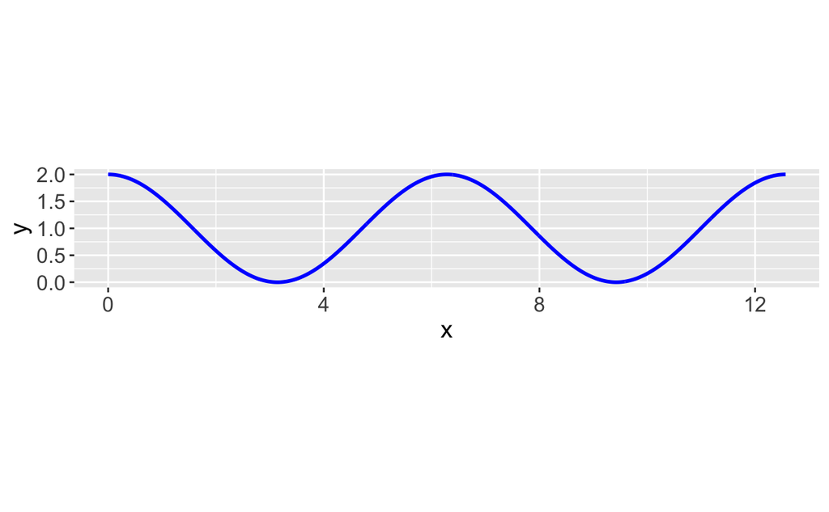

```r
x = function(t) t
y = function(t) cos(t)+1

plot_function(x, y, 0, 4*pi)
```

```r
print(suppressWarnings(paste("Arc Length:", arc_length(x,y, 0, 2*pi)+7)))
```

```
[1] "Arc Length: 28.9940885993921"
```

```r
print(suppressWarnings(paste("Area:", area(x,y, 0, 2*pi))))
```

```
[1] "Area: 6.28444206991706"
```

```r
print(suppressWarnings(paste("Polsby-Popper:", polsby_popper(x,y, 0, 2*pi, 7))))
```

```
[1] "Polsby-Popper: 0.0939415383878562"
```

So these sorts of districts that weave in and out of communities are really bad, and Polsby-Popper penalizes them for it: they are not compact. However, this also shows a flaw: what if you have a coastal district that geographically does this weaving? Nevertheless, it remains a good metric because it flags districts that *may* be problematic.

And finally, just because I wanted to, let’s look at the astroid!

$$x(t)=(\cos(t))^3$$
$$y(t)=(\sin(t))^3$$
$$0 \leq t \leq 2\pi$$

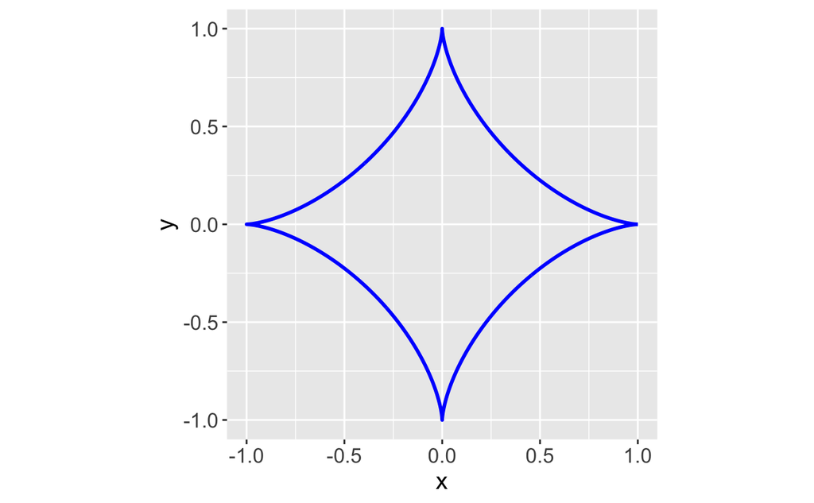

```r
x = function(t) (cos(t))^3
y = function(t) (sin(t))^3

plot_function(x, y, 0, 2*pi)
```

```r
print(suppressWarnings(paste("Arc Length:", arc_length(x,y, 0, 2*pi))))
```

```
[1] "Arc Length: 4.84422411027384"
```

```r
print(suppressWarnings(paste("Area:", area(x,y, 0, 2*pi))))
```

```
[1] "Area: 1.17809724509611"
```

```r
print(suppressWarnings(paste("Polsby-Popper:", polsby_popper(x,y, 0, 2*pi))))
```

```
[1] "Polsby-Popper: 0.630873885754706"
```

So the astroid actually makes relatively good use of its area. This example just goes to show that Polsby-Popper isn’t “foolproof,” and wonky districts like this may still pass the test or get a relatively compact score.

However, it’s a good indicator of compactness. Now we’ll look at some real districts!

## Gerrymandering Application

```r
# i'm importing the ALARM & redist library; it's a collection of redistricting data on all 50 states (properly credited in references)
library(alarmdata)
library(redist)
# this is the library we need to work with shapefiles (more on this soon)
library(sf)
```

```r
# basically, i'm importing data from Alabama
raw_map = alarm_50state_map("AL")
# then i'm getting rid of the "unnecessary data" (this library can do a lot of things -- we only need it for a very specific purpose)
map = raw_map[c(1,3,6,7,9,51)]
# with this, we're able to generate Multipolygon geometries
# so intuitively, this means that we get a collection of points that correspond to a district
map = redist_map(map, existing_plan=cd_2020, pop_tol=0.01, total_pop=pop)
```

Basically, the “geography” or district shape is stored in what is called a **shapefile**. To make shapefiles readable and usable, we convert it to a Multipolygon, just a collection of all the points on the shape.

Let’s take a look at what this means for Alabama as a whole. We are going to plot the Multipolygons onto Alabama!

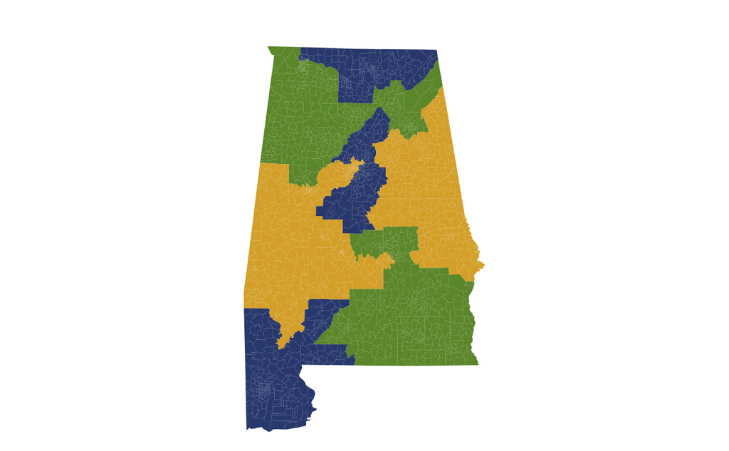

```r
redist.plot.map(shp=map, plan=map$cd_2020, boundaries=F)
```

Here’s an example visualization: we’re taking our “map” dataframe and asking it to find all the Multipolygons that correspond to the first district.

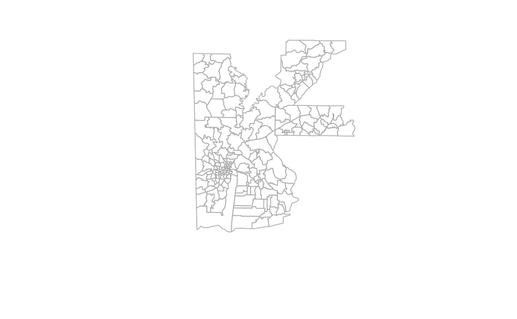

```r
shape_map_d1 = map %>% filter(cd_2020==1) %>% st_geometry()
plot(shape_map_d1, border = 'grey')
```

We can get one shape for the district by just taking the union of that plot above.

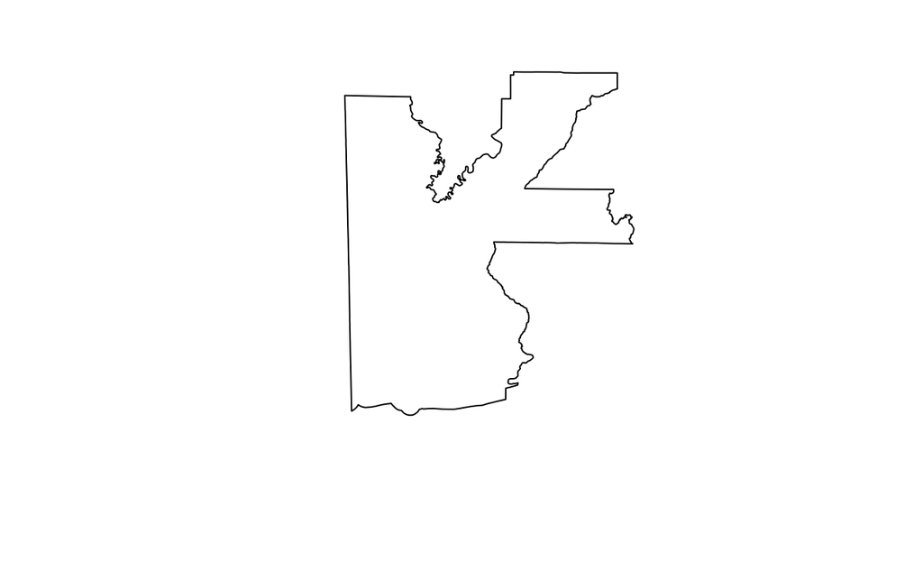

```r
full_shape_d1 = st_union(shape_map_d1)
plot(full_shape_d1)
```

Ok, now that we’ve laid that foundation, let’s do some redistricting analysis on Alabama. This could be generalized to many states, but I’m just highlighting one application here.

We’re going to write functions for area and perimeter, but it’s going to be a little different.

We have Multipolygons, which are just a collection of points. So we can’t necessarily use our parametric equations; we have to use a built-in function for area. For perimeter, I’ve just coded an application of the distance formula below: it looks like a lot, but we’re basically taking our collection of points (stored in `coords`), converting it to a data frame (`df_coords`), and then summing up the distance for all of the points. The input it takes in is our `full_shape` that we generated earlier.

```r
gerry_area = function(shape) {
  A = st_area(shape)
  return(A)
}

gerry_perimeter = function(shape) {

  coords = shape[[1]][[1]]
  df_coords = as.data.frame(coords)
  p_vec = list()
  for (x in 1:nrow(df_coords)-1) {
    x1 = df_coords[x, 1]
    x2 = df_coords[x+1, 1]
    y1 = df_coords[x, 2]
    y2 = df_coords[x+1, 2]
    distance = sqrt((x2-x1)^2 + (y2-y1)^2)
    p_vec[[x+1]] = distance
  }
  L = sum(unlist(p_vec))

  return (L)
}
```

We can also now write a new Polsby-Popper function as so.

```r
gerry_pp = function(shape) {
  A = gerry_area(shape)
  L = gerry_perimeter(shape)
  PP = 4*pi*A/L^2
  return (PP)
}
```

So let’s run it on Alabama’s districts! Down here, I’m just defining the geometries for each of Alabama’s 7 districts, like we did with the first one above.

```r
full_shape_d1 = st_union(map %>% filter(cd_2020==1) %>% st_geometry())
full_shape_d2 = st_union(map %>% filter(cd_2020==2) %>% st_geometry())
full_shape_d3 = st_union(map %>% filter(cd_2020==3) %>% st_geometry())
full_shape_d4 = st_union(map %>% filter(cd_2020==4) %>% st_geometry())
full_shape_d5 = st_union(map %>% filter(cd_2020==5) %>% st_geometry())
full_shape_d6 = st_union(map %>% filter(cd_2020==6) %>% st_geometry())
full_shape_d7 = st_union(map %>% filter(cd_2020==7) %>% st_geometry())
```

Now, we can run Polsby on each.

### District 1

Here’s the shape:

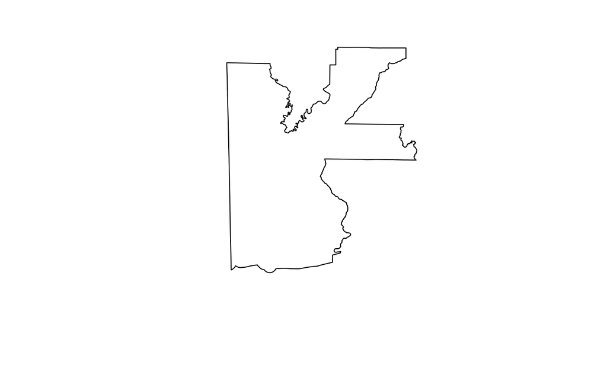

```r
plot(full_shape_d1)
```

And here’s our Polsby-Popper output:

```r
print(paste("Arc Length:", gerry_perimeter(full_shape_d1)))
```

```
[1] "Arc Length: 1007549.22112173"
```

```r
print(paste("Area:", gerry_area(full_shape_d1)))
```

```
[1] "Area: 17022780949.3073"
```

```r
print(paste("Polsby-Popper:", gerry_pp(full_shape_d1)))
```

```
[1] "Polsby-Popper: 0.210721006208348"
```

So that’s not very compact… Well, maybe it’s an outlier. Let’s check the rest (I’m going to forgo the explanations and I’ll sum up after everything)

### District 2

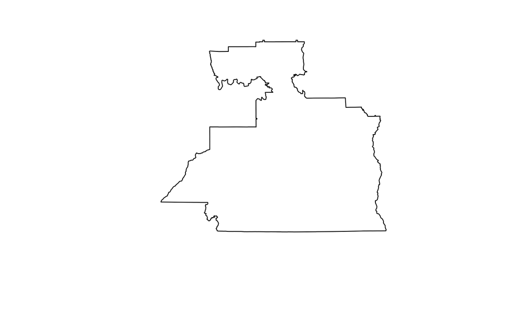

```r
plot(full_shape_d2)
```

```r
print(paste("Arc Length:", gerry_perimeter(full_shape_d2)))
```

```
[1] "Arc Length: 1106535.64396635"
```

```r
print(paste("Area:", gerry_area(full_shape_d2)))
```

```
[1] "Area: 27360506563.2425"
```

```r
print(paste("Polsby-Popper:", gerry_pp(full_shape_d2)))
```

```
[1] "Polsby-Popper: 0.280803930005818"
```

### District 3

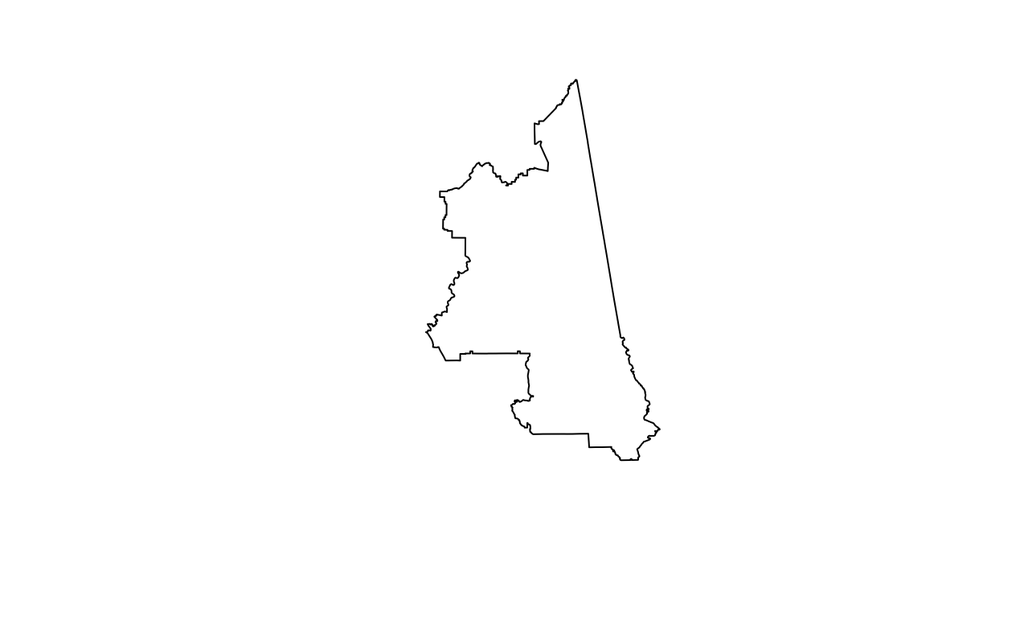

```r
plot(full_shape_d3)
```

```r
print(paste("Arc Length:", gerry_perimeter(full_shape_d3)))
```

```
[1] "Arc Length: 1015171.20942844"
```

```r
print(paste("Area:", gerry_area(full_shape_d3)))
```

```
[1] "Area: 21918379221.0289"
```

```r
print(paste("Polsby-Popper:", gerry_pp(full_shape_d3)))
```

```
[1] "Polsby-Popper: 0.267263539427327"
```

### District 4

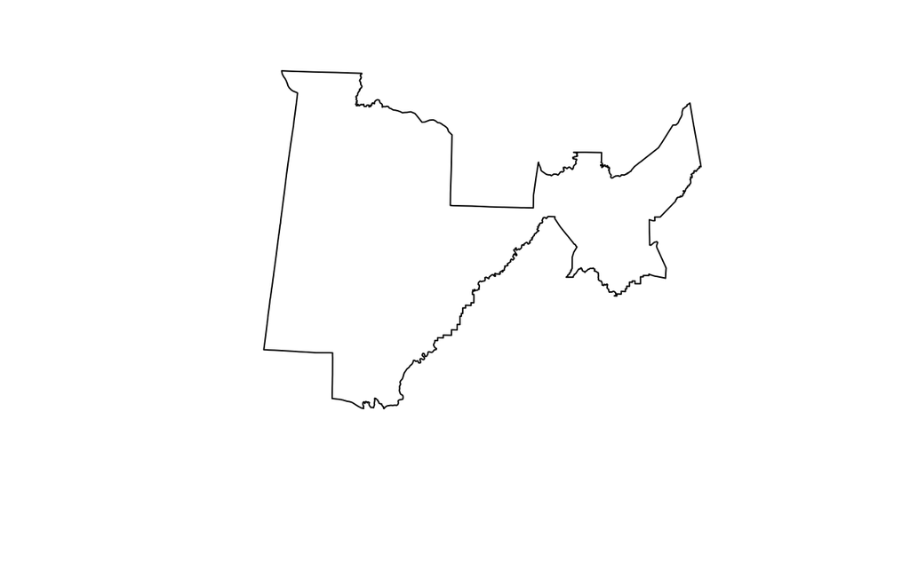

```r
plot(full_shape_d4)
```

```r
print(paste("Arc Length:", gerry_perimeter(full_shape_d4)))
```

```
[1] "Arc Length: 1208461.74444713"
```

```r
print(paste("Area:", gerry_area(full_shape_d4)))
```

```
[1] "Area: 23443408107.8319"
```

```r
print(paste("Polsby-Popper:", gerry_pp(full_shape_d4)))
```

```
[1] "Polsby-Popper: 0.201727356958331"
```

### District 5

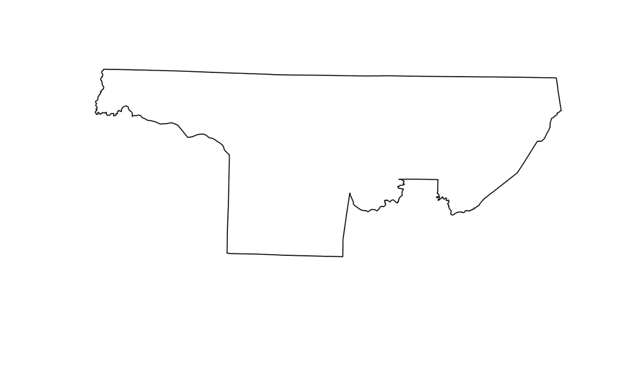

```r
plot(full_shape_d5)
```

```r
print(paste("Arc Length:", gerry_perimeter(full_shape_d5)))
```

```
[1] "Arc Length: 577331.247287134"
```

```r
print(paste("Area:", gerry_area(full_shape_d5)))
```

```
[1] "Area: 9093237999.87174"
```

```r
print(paste("Polsby-Popper:", gerry_pp(full_shape_d5)))
```

```
[1] "Polsby-Popper: 0.342829586346021"
```

### District 6

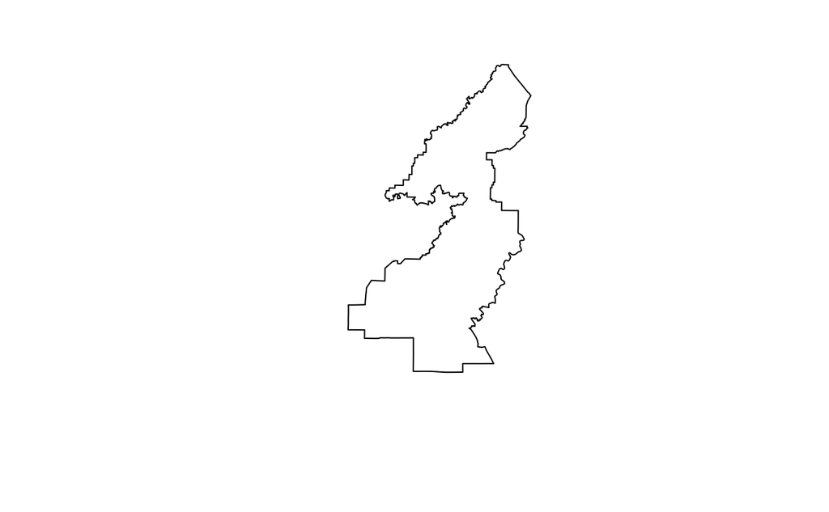

```r
plot(full_shape_d6)
```

```r
print(paste("Arc Length:", gerry_perimeter(full_shape_d6)))
```

```
[1] "Arc Length: 804936.091109583"
```

```r
print(paste("Area:", gerry_area(full_shape_d6)))
```

```
[1] "Area: 8432334395.63596"
```

```r
print(paste("Polsby-Popper:", gerry_pp(full_shape_d6)))
```

```
[1] "Polsby-Popper: 0.163544101055162"
```

### District 7

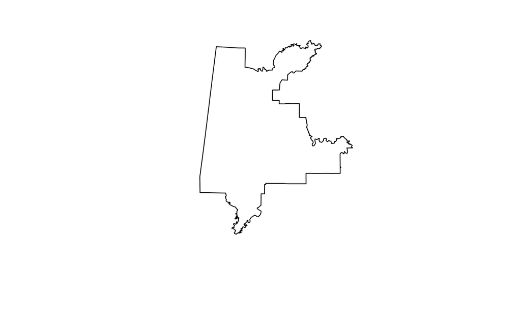

```r
plot(full_shape_d7)
```

```r
print(paste("Arc Length:", gerry_perimeter(full_shape_d7)))
```

```
[1] "Arc Length: 1338522.0120394"
```

```r
print(paste("Area:", gerry_area(full_shape_d7)))
```

```
[1] "Area: 28541497134.9033"
```

```r
print(paste("Polsby-Popper:", gerry_pp(full_shape_d7)))
```

```
[1] "Polsby-Popper: 0.20018686528721"
```

So let’s visualize our results: the figure below has each district labeled with its number and then the Polsby-Popper coefficient.

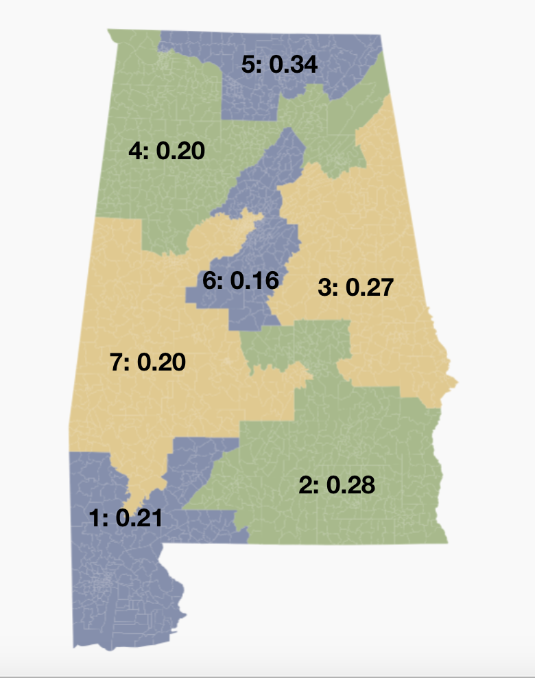

Representation of Alabama’s Districts with Polsby-Popper

As we can see, all the districts have a low score–which we can understand, considering we’re looking at sharp borders. But some districts are much better than other, and that tells us something.

## Analysis

Take a special look at district 7. District 7 is gerrymandered to pack the African-American populaion of Alabama into one district, thus limiting their influence. (The Supreme Court actually struck this map down for being an impermissible racial gerrymander under Section 2 of the Voting Rights Act in Allen v. Milligan (2023)).

District 7 has two “arms” or extensions, one reaching to the city of Birmingham, and the other reaching the city of Montgomery. So in this strategy to “pack” the African-American population, the map sacrifices compactness, and we see that with District 7 having a Polsby-Popper score of 0.20 (indicating that it is not compact at all).

And that influences the other districts around it. That’s why 6 has the lowest Polsby-Popper score, and 1 also has a low score of 0.21. In constrast, District 5, which isn’t gerrymandered and is a relatively nice shape, has the highest score of 0.34.

So Polsby-Popper, or the isoperimetric quotient, is a valuable tool for measuring the compactness of districts.

It has its flaws; most districts will most definitely not be circular (and really shouldn’t be), but it tells us something powerful about compactness.

The scientists who first proposed this algorithm for measuring gerrymandering emphasized that while it wasn’t perfect, it was another hurdle for gerrymander-ers to jump through. It makes maps like Alabama’s, especially districts like District 7, subject to more scrutiny. That’s an important step in getting fairer representation.